# Ex 22 Reshaping Data

## 22.1 Exercises

```r
library(tidyverse)
```

> 1. Run the following command to define the `co2_wide` object:

> ```r
> co2_wide <- data.frame(matrix(co2, ncol = 12, byrow = TRUE)) %>%
> setNames(1:12) %>%
> mutate(year = as.character(1959:1997))
> ```

> Use the gather function to wrangle this into a tidy dataset. Call the column with the CO2 measurements `co2` and call the month column `month`. Call the resulting object `co2_tidy`.

```r
str(co2)
```

```
##  Time-Series [1:468] from 1959 to 1998: 315 316 316 318 318 ...
```

```r
co2_wide <- data.frame(matrix(co2, ncol = 12, byrow = TRUE)) %>% setNames(1:12) %>% mutate(year=as.character(1959:1997))
co2_tidy <- data.frame(matrix(co2, ncol = 12, byrow = TRUE)) %>% setNames(1:12) %>% mutate(year=as.factor(1959:1997)) %>% gather(key=month, value=co2, -year, convert=TRUE)
str(co2_tidy)
```

```
## 'data.frame':    468 obs. of  3 variables:
##  $ year : Factor w/ 39 levels "1959","1960",..: 1 2 3 4 5 6 7 8 9 10 ...
##  $ month: int  1 1 1 1 1 1 1 1 1 1 ...
##  $ co2  : num  315 316 317 318 319 ...
```

```r
co2_tidy
```

| year | month | co2 |
| --- | --- | --- |
| 1959 | 1 | 315.42 |
| 1960 | 1 | 316.27 |
| 1961 | 1 | 316.73 |
| 1962 | 1 | 317.78 |
| 1963 | 1 | 318.58 |
| 1964 | 1 | 319.41 |
| 1965 | 1 | 319.27 |
| 1966 | 1 | 320.46 |
| 1967 | 1 | 322.17 |
| 1968 | 1 | 322.40 |

[output cut: 458 more lines]

> 2. Plot CO2 versus month with a different curve for each year using this code:

> ```r
> co2_tidy %>% ggplot(aes(month, co2, color = year)) + geom_line()
> ```

> If the expected plot is not made, it is probably because `co2_tidy$month` is not numeric:

> ```r
> class(co2_tidy$month)
> ```

> Rewrite the call to gather using an argument that assures the month column will be numeric. Then make the plot.

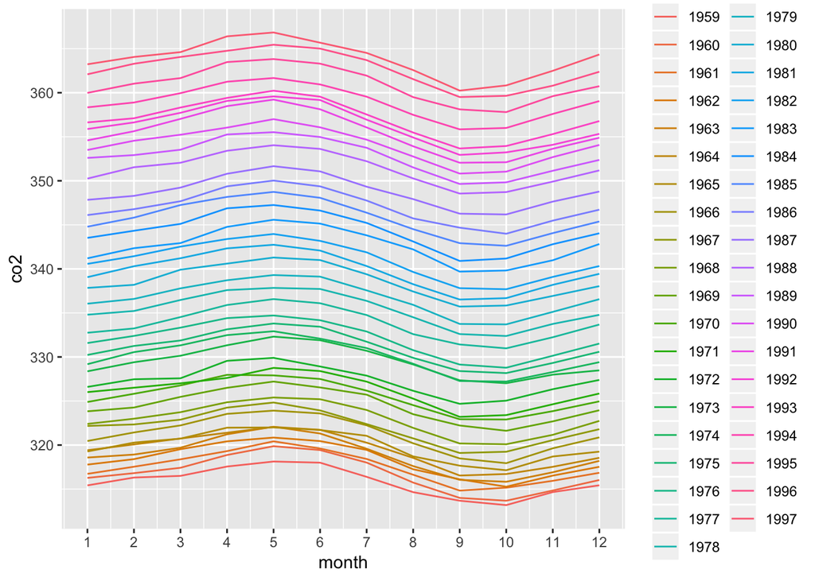

```r
co2_tidy %>% ggplot(aes(month, co2, color = year)) + geom_line() + scale_x_continuous(breaks = c(1:12))
```

> 3. What do we learn from this plot?

> A. CO2 measures increase monotonically from 1959 to 1997.

> B. CO2 measures are higher in the summer and the yearly average increased from 1959 to 1997.

> C. CO2 measures appear constant and random variability explains the differences.

> D. CO2 measures do not have a seasonal trend.

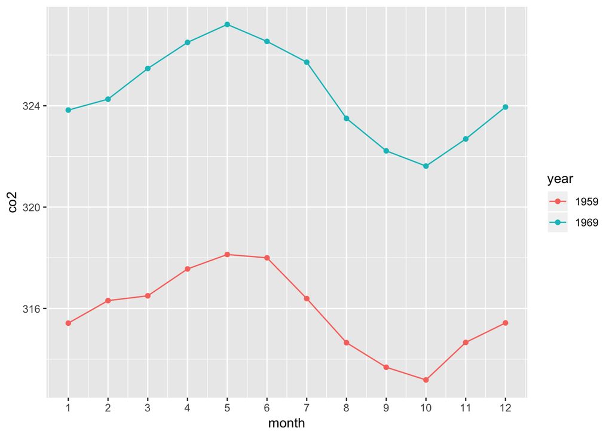

```r
co2_tidy %>% filter(year==1959 | year==1969) %>% ggplot(aes(month, co2, color = year)) + geom_point() + geom_line() + scale_x_continuous(breaks = c(1:12))
```

> 4. Now load the `admissions` data set, which contains admission information for men and women across six majors and keep only the admitted percentage column:

> ```r
> load(admissions)
> dat <- admissions %>% select(-applicants)
> ```

> If we think of an observation as a major, and that each observation has two variables (men admitted percentage and women admitted percentage) then this is not tidy. Use the `spread` function to wrangle into tidy shape: one row for each major.

```r
library(dslabs)
data(admissions)
dat <- admissions %>% select(-applicants)
dat %>% spread(gender,admitted)
```

| major | men | women |
| --- | --- | --- |
| A | 62 | 82 |
| B | 63 | 68 |
| C | 37 | 34 |
| D | 33 | 35 |
| E | 28 | 24 |
| F | 6 | 7 |

> 5. Now we will try a more advanced wrangling challenge. We want to wrangle the admissions data so that for each major we have 4 observations: `admitted_men`, `admitted_women`, `applicants_men` and `applicants_women`. The *trick* we perform here is actually quite common: first gather to generate an intermediate data frame and then spread to obtain the tidy data we want. We will go step by step in this and the next two exercises.

> Use the gather function to create a `tmp` data.frame with a column containing the type of observation `admitted` or `applicants`. Call the new columns `key` and value.

```r
tmp_gather <- admissions %>% gather(key, value, -major,-gender)
tmp_gather
```

| major | gender | key | value |
| --- | --- | --- | --- |
| A | men | admitted | 62 |
| B | men | admitted | 63 |
| C | men | admitted | 37 |
| D | men | admitted | 33 |
| E | men | admitted | 28 |
| F | men | admitted | 6 |
| A | women | admitted | 82 |
| B | women | admitted | 68 |
| C | women | admitted | 34 |
| D | women | admitted | 35 |

[output cut: 14 more lines]

> 6. Now you have an object `tmp` with columns `major`, `gender`, `key` and `value`. Note that if you combine the key and gender, we get the column names we want: `admitted_men`, `admitted_women`, `applicants_men` and `applicants_women`. Use the function `unite` to create a new column called `column_name`.

```r
tmp_unite <- tmp_gather %>% unite(column_name, key, gender, -major, -value)
tmp_unite
```

| major | column_name | value |
| --- | --- | --- |
| A | admitted_men | 62 |
| B | admitted_men | 63 |
| C | admitted_men | 37 |
| D | admitted_men | 33 |
| E | admitted_men | 28 |
| F | admitted_men | 6 |
| A | admitted_women | 82 |
| B | admitted_women | 68 |
| C | admitted_women | 34 |
| D | admitted_women | 35 |

[output cut: 14 more lines]

> 7. Now use the `spread` function to generate the tidy data with four variables for each major.

```r
tmp_unite %>% spread(column_name, value)
```

| major | admitted_men | admitted_women | applicants_men | applicants_women |
| --- | --- | --- | --- | --- |
| A | 62 | 82 | 825 | 108 |
| B | 63 | 68 | 560 | 25 |
| C | 37 | 34 | 325 | 593 |
| D | 33 | 35 | 417 | 375 |
| E | 28 | 24 | 191 | 393 |
| F | 6 | 7 | 373 | 341 |

> 8. Now use the pipe to write a line of code that turns `admissions` to the table produced in the previous exercise.

```r
admissions %>% gather(key, value, -major,-gender) %>% unite(column_name, key, gender, -major, -value) %>% spread(column_name,value)
```

| major | admitted_men | admitted_women | applicants_men | applicants_women |
| --- | --- | --- | --- | --- |
| A | 62 | 82 | 825 | 108 |
| B | 63 | 68 | 560 | 25 |
| C | 37 | 34 | 325 | 593 |
| D | 33 | 35 | 417 | 375 |
| E | 28 | 24 | 191 | 393 |
| F | 6 | 7 | 373 | 341 |

## 22.2 Additional Exercises

> 1. Examine the dataset `co2`. Which of the following is true:

> A. `co2` is tidy data: it has one year for each row.

> B. `co2` is not tidy: we need at least one column with a character vector.

> C. `co2` is not tidy: it is a matrix not a data frame.

> D. `co2` is not tidy: to be tidy we would have to wrangle it to have three columns: year, month and value; then each co2 observation has a row.

Answer D.

Definition of **tidy data** from this chapter is as follows: *each row represents one observation and the columns represent the different variables available for each of these observations*

According to this defintion the time-series object does not define a tidy data set, because it is not defined wich observation belongs to which point in time. Therefore, answer D is the most likely one. The calculations below show that the object Time-Series contains 468 data points for each month for 39 years between 1959 and 1998, which are 468 points total.

In the following I will reshape the data into a tidy form. However, after reading the exercise of this chapter I found that there is a more elegant solution by using the tidyverse functions. Anyway, here is the hard way by foot to get to the tidy dataset.

```r
library(tidyverse)
library(dslabs)
data("co2")
str(co2)
```

```
##  Time-Series [1:468] from 1959 to 1998: 315 316 316 318 318 ...
```

```r
length(co2)
```

```
## [1] 468
```

```r
(1998-1959)*12
```

```
## [1] 468
```

```r
months <- rep(1:12,39)
years <- rep(1959:1997,12)
years <- sort(years)
tab_co2 <- as.tibble(cbind(years,months,co2)) %>% arrange(years,months)
tab_co2
```

| years | months | co2 |
| --- | --- | --- |
| 1959 | 1 | 315.42 |
| 1959 | 2 | 316.31 |
| 1959 | 3 | 316.50 |
| 1959 | 4 | 317.56 |
| 1959 | 5 | 318.13 |
| 1959 | 6 | 318.00 |
| 1959 | 7 | 316.39 |
| 1959 | 8 | 314.65 |
| 1959 | 9 | 313.68 |
| 1959 | 10 | 313.18 |

[output cut: 458 more lines]

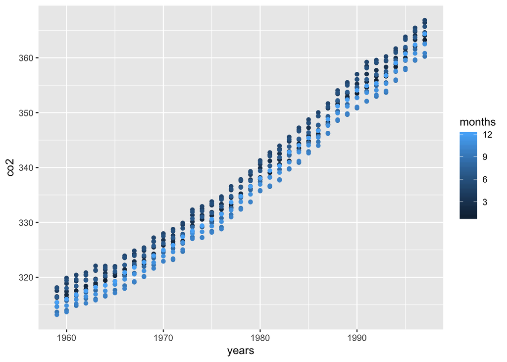

```r
tab_co2 %>% ggplot(aes(years,co2,col=months)) + geom_point()
```

> 2. Examine the dataset `ChickWeight`. Which of the following is true:
> 1. `ChickWeight` is not tidy: each chick has more than one row.
> 2. `ChickWeight` is tidy: each observation, here a weight, is represented by one row. The chick from which this measurement came from is one the variables.
> 3. `ChickWeight` is not a tidy: we are missing the year column.
> 4. `ChickWeight` is tidy: it is stored in a data frame.

Answer B.

```r
data(ChickWeight)
ChickWeight
```

|  | weight | Time | Chick | Diet |
| --- | --- | --- | --- | --- |
| 1 | 42 | 0 | 1 | 1 |
| 2 | 51 | 2 | 1 | 1 |
| 3 | 59 | 4 | 1 | 1 |
| 4 | 64 | 6 | 1 | 1 |
| 5 | 76 | 8 | 1 | 1 |
| 6 | 93 | 10 | 1 | 1 |
| 7 | 106 | 12 | 1 | 1 |
| 8 | 125 | 14 | 1 | 1 |
| 9 | 149 | 16 | 1 | 1 |
| 10 | 171 | 18 | 1 | 1 |

[output cut: 568 more lines]

```r
str(ChickWeight)
```

```
## Classes 'nfnGroupedData', 'nfGroupedData', 'groupedData' and 'data.frame':   578 obs. of  4 variables:
##  $ weight: num  42 51 59 64 76 93 106 125 149 171 ...
##  $ Time  : num  0 2 4 6 8 10 12 14 16 18 ...
##  $ Chick : Ord.factor w/ 50 levels "18"<"16"<"15"<..: 15 15 15 15 15 15 15 15 15 15 ...
##  $ Diet  : Factor w/ 4 levels "1","2","3","4": 1 1 1 1 1 1 1 1 1 1 ...
##  - attr(*, "formula")=Class 'formula'  language weight ~ Time | Chick
##   .. ..- attr(*, ".Environment")=<environment: R_EmptyEnv>
##  - attr(*, "outer")=Class 'formula'  language ~Diet
##   .. ..- attr(*, ".Environment")=<environment: R_EmptyEnv>
##  - attr(*, "labels")=List of 2
##   ..$ x: chr "Time"
##   ..$ y: chr "Body weight"
##  - attr(*, "units")=List of 2
##   ..$ x: chr "(days)"
##   ..$ y: chr "(gm)"
```

```r
class(ChickWeight)
```

```
## [1] "nfnGroupedData" "nfGroupedData"  "groupedData"    "data.frame"
```

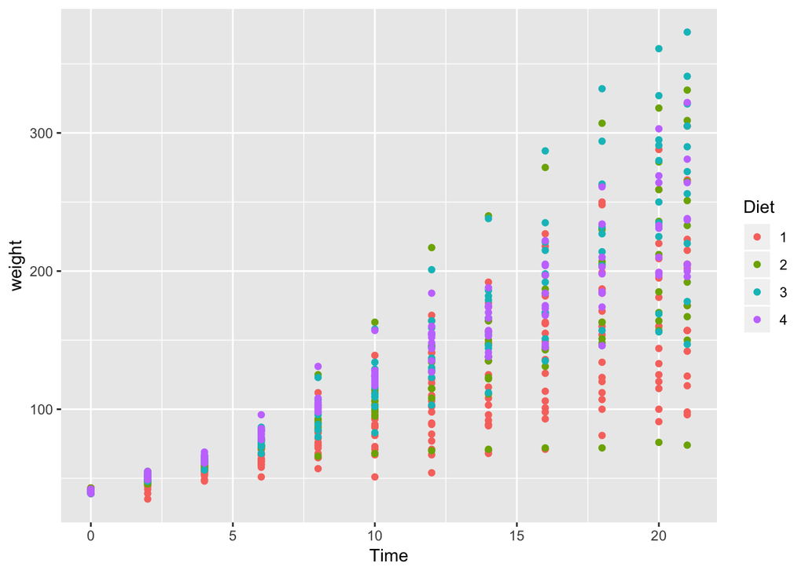

```r
ChickWeight %>% ggplot(aes(Time,weight,col=Diet)) + geom_point()
```

> 3. Examine the dataset `BOD`. Which of the following is true:

> A. `BOD` is not tidy: it only has six rows.

> B. `BOD` is not tidy: the first column is just an index.

> C. `BOD` is tidy: each row is an observation with two values, time and demand.

> D. `BOD` is tidy: all small datasets are tidy by definition.

Anser C.

```r
data(BOD)
BOD
```

| Time | demand |
| --- | --- |
| 1 | 8.3 |
| 2 | 10.3 |
| 3 | 19.0 |
| 4 | 16.0 |
| 5 | 15.6 |
| 7 | 19.8 |

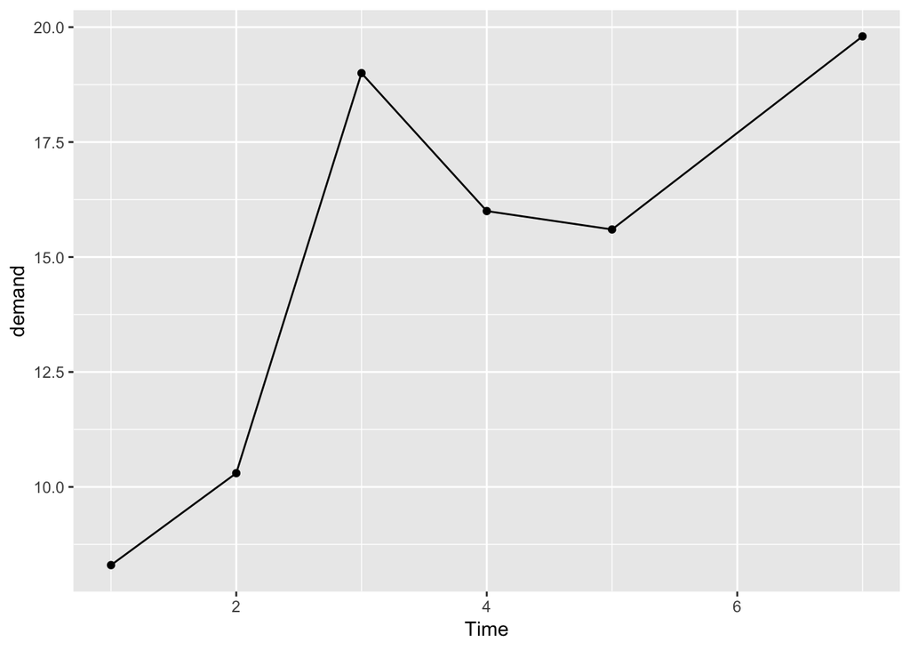

```r
BOD %>% ggplot(aes(Time,demand)) + geom_line() + geom_point()
```

> 4. Which of the following datasets is tidy (you can pick more than one):

> A. `BJsales`

> B. `EuStockMarkets`

> C. `DNase`

> D. `Formaldehyde`

> E. `Orange`

> F. `UCBAdmissions`

Answers C,D and E.

The datasets, which were plotted below are tidy datasets. These are DNase, Formaldehyde and Orange, because each observation is in a row and each column is a variable that describes the observation. The first two datasets BJsales and EuStockMarkets are time-series and need further transformation to be tidy. The dataset UCBAdmissions contains tabulated data within a table and is not tidy.

```r
data(BJsales)
str(BJsales)
```

```
##  Time-Series [1:150] from 1 to 150: 200 200 199 199 199 ...
```

```r
data(EuStockMarkets)
str(EuStockMarkets)
```

```
##  Time-Series [1:1860, 1:4] from 1991 to 1999: 1629 1614 1607 1621 1618 ...
##  - attr(*, "dimnames")=List of 2
##   ..$ : NULL
##   ..$ : chr [1:4] "DAX" "SMI" "CAC" "FTSE"
```

```r
data(DNase)
str(DNase)
```

```
## Classes 'nfnGroupedData', 'nfGroupedData', 'groupedData' and 'data.frame':   176 obs. of  3 variables:
##  $ Run    : Ord.factor w/ 11 levels "10"<"11"<"9"<..: 4 4 4 4 4 4 4 4 4 4 ...
##  $ conc   : num  0.0488 0.0488 0.1953 0.1953 0.3906 ...
##  $ density: num  0.017 0.018 0.121 0.124 0.206 0.215 0.377 0.374 0.614 0.609 ...
##  - attr(*, "formula")=Class 'formula'  language density ~ conc | Run
##   .. ..- attr(*, ".Environment")=<environment: R_EmptyEnv>
##  - attr(*, "labels")=List of 2
##   ..$ x: chr "DNase concentration"
##   ..$ y: chr "Optical density"
##  - attr(*, "units")=List of 1
##   ..$ x: chr "(ng/ml)"
```

```r
DNase
```

|  | Run | conc | density |
| --- | --- | --- | --- |
| 1 | 1 | 0.04882812 | 0.017 |
| 2 | 1 | 0.04882812 | 0.018 |
| 3 | 1 | 0.19531250 | 0.121 |
| 4 | 1 | 0.19531250 | 0.124 |
| 5 | 1 | 0.39062500 | 0.206 |
| 6 | 1 | 0.39062500 | 0.215 |
| 7 | 1 | 0.78125000 | 0.377 |
| 8 | 1 | 0.78125000 | 0.374 |
| 9 | 1 | 1.56250000 | 0.614 |
| 10 | 1 | 1.56250000 | 0.609 |

[output cut: 166 more lines]

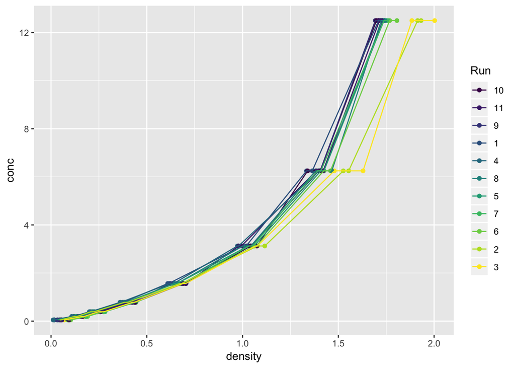

```r
DNase %>% ggplot(aes(density,conc,col=Run)) + geom_point() + geom_line()
```

```r
data(Formaldehyde)
str(Formaldehyde)
```

```
## 'data.frame':    6 obs. of  2 variables:
##  $ carb  : num  0.1 0.3 0.5 0.6 0.7 0.9
##  $ optden: num  0.086 0.269 0.446 0.538 0.626 0.782
```

```r
Formaldehyde
```

|  | carb | optden |
| --- | --- | --- |
| 1 | 0.1 | 0.086 |
| 2 | 0.3 | 0.269 |
| 3 | 0.5 | 0.446 |
| 4 | 0.6 | 0.538 |
| 5 | 0.7 | 0.626 |
| 6 | 0.9 | 0.782 |

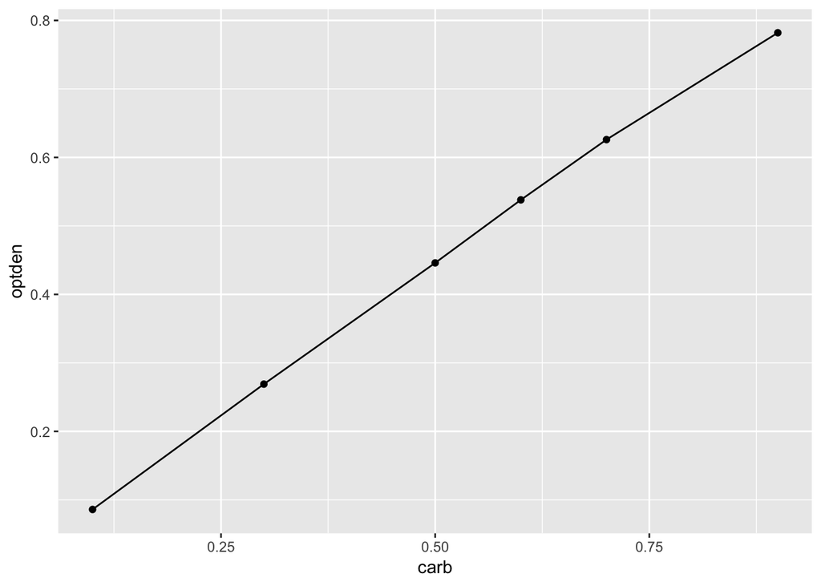

```r
Formaldehyde %>% ggplot(aes(carb,optden)) + geom_line() + geom_point()
```

```r
data(Orange)
str(Orange)
```

```
## Classes 'nfnGroupedData', 'nfGroupedData', 'groupedData' and 'data.frame':   35 obs. of  3 variables:
##  $ Tree         : Ord.factor w/ 5 levels "3"<"1"<"5"<"2"<..: 2 2 2 2 2 2 2 4 4 4 ...
##  $ age          : num  118 484 664 1004 1231 ...
##  $ circumference: num  30 58 87 115 120 142 145 33 69 111 ...
##  - attr(*, "formula")=Class 'formula'  language circumference ~ age | Tree
##   .. ..- attr(*, ".Environment")=<environment: R_EmptyEnv>
##  - attr(*, "labels")=List of 2
##   ..$ x: chr "Time since December 31, 1968"
##   ..$ y: chr "Trunk circumference"
##  - attr(*, "units")=List of 2
##   ..$ x: chr "(days)"
##   ..$ y: chr "(mm)"
```

```r
Orange
```

|  | Tree | age | circumference |
| --- | --- | --- | --- |
| 1 | 1 | 118 | 30 |
| 2 | 1 | 484 | 58 |
| 3 | 1 | 664 | 87 |
| 4 | 1 | 1004 | 115 |
| 5 | 1 | 1231 | 120 |
| 6 | 1 | 1372 | 142 |
| 7 | 1 | 1582 | 145 |
| 8 | 2 | 118 | 33 |
| 9 | 2 | 484 | 69 |
| 10 | 2 | 664 | 111 |

[output cut: 25 more lines]

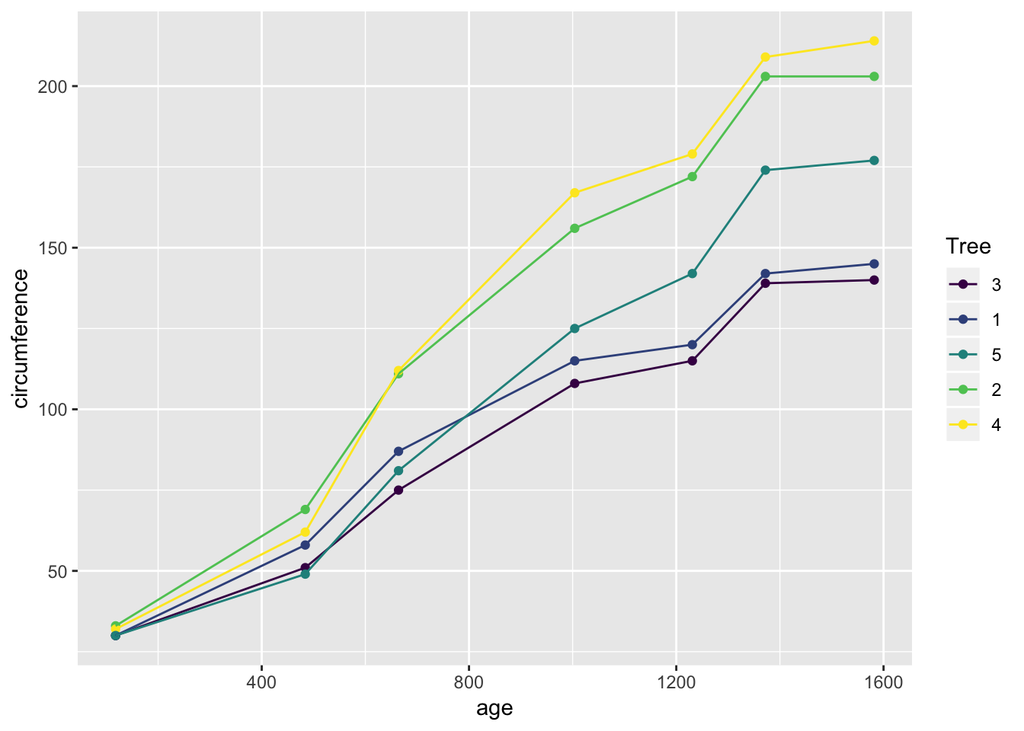

```r
Orange %>% ggplot(aes(age,circumference,col=Tree)) + geom_point() + geom_line()
```

```r
data(UCBAdmissions)
str(UCBAdmissions)
```

```
##  'table' num [1:2, 1:2, 1:6] 512 313 89 19 353 207 17 8 120 205 ...
##  - attr(*, "dimnames")=List of 3
##   ..$ Admit : chr [1:2] "Admitted" "Rejected"
##   ..$ Gender: chr [1:2] "Male" "Female"
##   ..$ Dept  : chr [1:6] "A" "B" "C" "D" ...
```

```r
UCBAdmissions
```

```
## , , Dept = A
##
##           Gender
## Admit      Male Female
##   Admitted  512     89
##   Rejected  313     19
##
## , , Dept = B
##
##           Gender
## Admit      Male Female
##   Admitted  353     17
##   Rejected  207      8
##
## , , Dept = C
##
##           Gender
## Admit      Male Female
##   Admitted  120    202
##   Rejected  205    391
##
## , , Dept = D
##
##           Gender
## Admit      Male Female
##   Admitted  138    131
##   Rejected  279    244
##
## , , Dept = E
##
##           Gender
## Admit      Male Female
##   Admitted   53     94
##   Rejected  138    299
##
## , , Dept = F
##
##           Gender
## Admit      Male Female
##   Admitted   22     24
##   Rejected  351    317
```